# Peer-graded Assignment: Prediction Assignment Writeup

Neha

7/29/2020

## Course Project : Practical Machine Learning : Analysing Quality of Physical Excercise.

### Synopsis

The Project aims at using large amount of data from devices such as Jawbone Up, Nike FuelBand, and Fitbit to quantify how well the individuals are doing the respective exercises. The data was obtained from accelerometers on the belt, forearm, arm, and dumbell of 6 participants. The participants were asked to perform barbell lifts correctly and incorrectly in 5 different ways and the data was used to train a prediction algorithm to judge the quality of exercise. The best algorithm was used to predict the quality of test dataset of unknown quality.

#### Setup

This code sets the global display to always include codes and loads the required libraries.

```r
library(ggplot2)
suppressMessages(library(caret))
suppressMessages(library(randomForest))
suppressMessages(library(rattle))
```

#### Data downloading

The data is downloaded from the mentioned links and loaded into R environment. The data was briefly explored to undertand the structure and the variables.

```r
url_train <- "https://d396qusza40orc.cloudfront.net/predmachlearn/pml-training.csv"
Training_data<- read.csv(url_train, na.strings = c("", "NA"))
dim(Training_data)
```

```
## [1] 19622   160
```

```r
#head(Training_data) #commented to reduce output
url_test <- "https://d396qusza40orc.cloudfront.net/predmachlearn/pml-testing.csv"
Test_data <- read.csv(url_test, na.strings = c("", "NA"))
dim(Test_data)
```

```
## [1]  20 160
```

```r
#head(Test_data) #commented to reduce output
```

#### Data partitioning

The Training data was partitioned into training set and test set for cross validation. The Training set consisted of 70% of the dataset while the test set consisted of 30% of the dataset

```r
# partition the training data into training and test(cross validation) set
set.seed(230)
inTrain <- createDataPartition(y=Training_data$classe, p=0.7, list=F)
Training <- Training_data[inTrain, ]
Test <- Training_data[-inTrain, ]
```

#### Tidying Data and Selecting Features

This was done in three steps:

```
1. All variables with very small/negligible variations were excluded from use in the model.
2. A number of columns had "NA" in most rows, all columns with "NA" in them were excluded.
3. The columns with names of participants and other features unfit for predictive purposes were excluded.
```

```r
#removing near-zero variance predictors
Zero_Var <- nearZeroVar(Training_data)
Training <- Training[, -Zero_Var]
Test <-Test[, -Zero_Var]
#removing all predictors with any NA value
Training <- Training[, colSums(is.na(Training)) == 0]
Test <- Test[, colSums(is.na(Test)) == 0]
#removing columns unfit for prediction (ID, user_name, raw_timestamp_part_1,etc.)
Training <- Training[, -(1:7)]
Test <- Test[, -(1:7)]
```

#### Model Selection

Three different machine learning algorithms were applied on the training set and tested for accuracy on the test set. These included:

```
1. Recursive Partitioning and Regression Trees (rpart)
2. Linear discriminant analysis (LDA)
3. Random forest (rf)
```

#### Recursive Partitioning and Regression Trees (rpart)

```r
#training the algorithm using training set
tree_model <- train(classe~., method="rpart", data = Training)
#predicting for the test set using the trained algorithm
prediction_tree <- predict(tree_model, Test)
#checking the accuracy of predictions
confusionMatrix(Test$classe, prediction_tree)
```

```
## Confusion Matrix and Statistics
##
##           Reference
## Prediction    A    B    C    D    E
##          A 1492   44  104   26    8
##          B  422  431  237   49    0
##          C  460   40  405  121    0
##          D  392  198  139  235    0
##          E  238  235  252   43  314
##
## Overall Statistics
##
##                Accuracy : 0.4889
##                  95% CI : (0.476, 0.5017)
##     No Information Rate : 0.5105
##     P-Value [Acc > NIR] : 0.9996
##
##                   Kappa : 0.3333
##
##  Mcnemar's Test P-Value : <2e-16
##
## Statistics by Class:
##
##                      Class: A Class: B Class: C Class: D Class: E
## Sensitivity            0.4967  0.45464  0.35620  0.49578  0.97516
## Specificity            0.9368  0.85659  0.86921  0.86527  0.86194
## Pos Pred Value         0.8913  0.37840  0.39474  0.24378  0.29020
## Neg Pred Value         0.6409  0.89107  0.84935  0.95143  0.99833
## Prevalence             0.5105  0.16109  0.19320  0.08054  0.05472
## Detection Rate         0.2535  0.07324  0.06882  0.03993  0.05336
## Detection Prevalence   0.2845  0.19354  0.17434  0.16381  0.18386
## Balanced Accuracy      0.7167  0.65562  0.61270  0.68053  0.91855
```

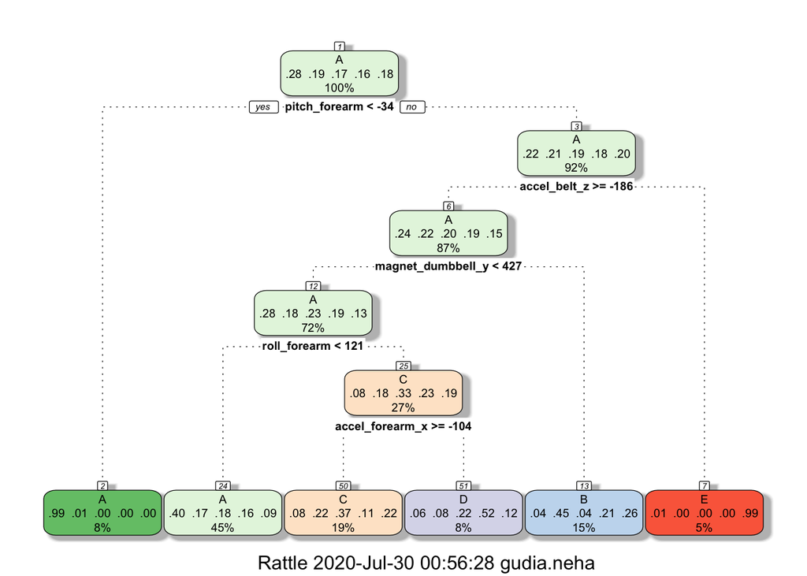

```r
# visualizing the tree created
fancyRpartPlot(tree_model$finalModel)
```

The method is less time consuming and gives a visual advantage but has very poor accuracy of 48.8870008

#### Linear discriminant analysis (LDA)

```r
#training the algorithm using training set
lda_model<- train(classe~., method="lda", data = Training)
#predicting for the test set using the trained algorithm
prediction_lda <- predict(lda_model, Test)
#checking the accuracy of predictions
confusionMatrix(Test$classe, prediction_lda )
```

```
## Confusion Matrix and Statistics
##
##           Reference
## Prediction    A    B    C    D    E
##          A 1360   32  156  121    5
##          B  161  744  128   44   62
##          C  101  111  656  136   22
##          D   49   62  109  683   61
##          E   44  201  126  114  597
##
## Overall Statistics
##
##                Accuracy : 0.6865
##                  95% CI : (0.6745, 0.6983)
##     No Information Rate : 0.2914
##     P-Value [Acc > NIR] : < 2.2e-16
##
##                   Kappa : 0.6034
##
##  Mcnemar's Test P-Value : < 2.2e-16
##
## Statistics by Class:
##
##                      Class: A Class: B Class: C Class: D Class: E
## Sensitivity            0.7930   0.6470   0.5583   0.6220   0.7992
## Specificity            0.9247   0.9166   0.9214   0.9413   0.9056
## Pos Pred Value         0.8124   0.6532   0.6394   0.7085   0.5518
## Neg Pred Value         0.9157   0.9145   0.8932   0.9157   0.9688
## Prevalence             0.2914   0.1954   0.1997   0.1866   0.1269
## Detection Rate         0.2311   0.1264   0.1115   0.1161   0.1014
## Detection Prevalence   0.2845   0.1935   0.1743   0.1638   0.1839
## Balanced Accuracy      0.8589   0.7818   0.7399   0.7817   0.8524
```

Time wise the is very economical but accuracy is still poor at 68.6491079.

#### Random forest (rf)

```r
#training the algorithm using training set
rf_model <- train(classe ~., method = "rf", data = Training, ntree=250)
#predicting for the test set using the trained algorithm
prediction_rf <- predict(rf_model, Test)
#checking the accuracy of predictions
confusionMatrix(Test$classe, prediction_rf )
```

```
## Confusion Matrix and Statistics
##
##           Reference
## Prediction    A    B    C    D    E
##          A 1670    4    0    0    0
##          B    6 1127    6    0    0
##          C    0    7 1018    1    0
##          D    0    0    8  955    1
##          E    0    0    1    2 1079
##
## Overall Statistics
##
##                Accuracy : 0.9939
##                  95% CI : (0.9915, 0.9957)
##     No Information Rate : 0.2848
##     P-Value [Acc > NIR] : < 2.2e-16
##
##                   Kappa : 0.9923
##
##  Mcnemar's Test P-Value : NA
##
## Statistics by Class:
##
##                      Class: A Class: B Class: C Class: D Class: E
## Sensitivity            0.9964   0.9903   0.9855   0.9969   0.9991
## Specificity            0.9990   0.9975   0.9984   0.9982   0.9994
## Pos Pred Value         0.9976   0.9895   0.9922   0.9907   0.9972
## Neg Pred Value         0.9986   0.9977   0.9969   0.9994   0.9998
## Prevalence             0.2848   0.1934   0.1755   0.1628   0.1835
## Detection Rate         0.2838   0.1915   0.1730   0.1623   0.1833
## Detection Prevalence   0.2845   0.1935   0.1743   0.1638   0.1839
## Balanced Accuracy      0.9977   0.9939   0.9919   0.9975   0.9992
```

The random forest is been told to be the most accurate giving an accuracy of 99.3882753. However the time taken for development of the model is long.

#### Conclusion

Out of the three predictive models, random forest gives the most accurate predictions. Thus we will use the random forest model to make predictions on the testing data provided with the question.

#### Prediction on Testing data

```r
testing_rf <- predict(rf_model, Test_data)
testing_rf
```

```
##  [1] B A B A A E D B A A B C B A E E A B B B
## Levels: A B C D E
```

```r
cases <- Test_data$X
data.frame(cases, testing_rf)
```

```
##    cases testing_rf
## 1      1          B
## 2      2          A
## 3      3          B
## 4      4          A
## 5      5          A
## 6      6          E
## 7      7          D
## 8      8          B
## 9      9          A
## 10    10          A
## 11    11          B
## 12    12          C
## 13    13          B
## 14    14          A
## 15    15          E
## 16    16          E
## 17    17          A
## 18    18          B
## 19    19          B
## 20    20          B
```